# 2. Linear Regression

## 2. 선형 회귀 ( Linear Regression )

오랫동안 귀뚜라미는 시원날 날보다 더운 날 더 자주 우는 것으로 알려져 왔습니다.  
전문가 및 아마추어 곤충 학자들이 수십 년에 걸쳐서 1분당 귀뚜라미가 우는 횟수와 온도에 관한 데이터를 목록으로 작성했습니다.  
고모가 생일 선물로 두 특성의 관계를 예측하는 모델을 학습시켜 보라고 아끼던 귀뚜라미 데이터베이스를 줬다고 해 봅시다.

올바른 첫 번째 단계는 데이터를 그래프로 만들어 검토하는 것입니다.

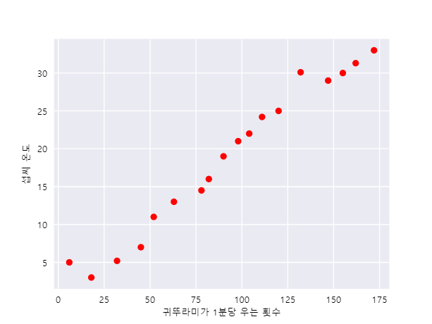

```
                                    < 그림 1. 1분당 우는 횟수 및 섭씨온도 >
```

예상대로 그래프를 통해 우는 횟수가 증가할수록 온도가 올라가는 것을 확인했습니다.  
우는 횟수와 온도는 선형 관계일까요? 네. 이 관계를 근사치로 하는 다음과 같은 하나의 직선을 그릴 수 있습니다.

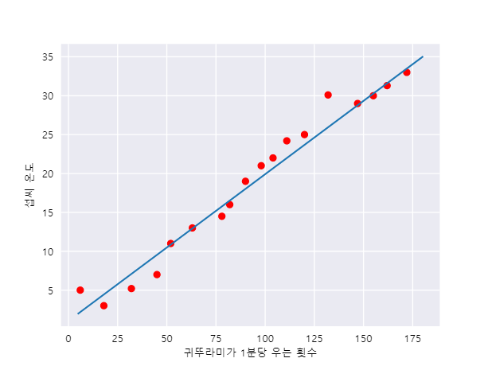

```
                                           < 그림 2. 선형 관계 >
```

여기서

[output not shown]

여기서

[output not shown]

새로운 분당 우는 횟수 x₁에서 온도 y′을 추론( 예측 )하려면 x₁값을 이 모델에 삽입하기만 하면 됩니다.

아래 첨자( 예: x₁, w₁)는 여러 특성에 의존하는 좀 더 정교한 모델을 예시합니다. 예를 들어 3가지 특성에 의존하는 모델은 다음과 같은 방정식으로 표현합니다.

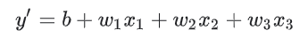

### 용어 정리

1. 편향 ( bias )  
   원점을 기준으로 한 offset, 머신러닝 모델에서 'b' 또는 'w₀'로 표현된다. 즉 입력 특성값인 'x'와 관계없이 일정한 값 ( 직선의 y절편 )
1. 추론 ( inference )  
   머신러닝에서 학습된 모델을 라벨에 없는 예에 적용하여 예측을 수행하는 과정을 의미한다.  
   통계학에서는 특정한 관찰 데이터에 맞게 분포의 매개변수를 조정하는 과정을 의미한다.
1. 가중치 ( weight )  
   선형 모델에서 특성의 개수 또는 심층 네트워크의 엣지입니다.  
   선형 모델 학습의 목표는 각 특성의 이상적인 가중치를 결정하는 것이다.  
   가중치가 0인 특성은 모델에 영향을 주지 않는다.
1. 선형 회귀 ( Linear Regression )  
   입력 특성( x₀, x₁, x₂,... )의 선형 조합( 위와 같은 방정식들 )으로부터 연속 값을 출력한다.

### 학습 및 손실

모델을 학습시킨다는 것은 단순히 말하자면, 라벨이 있는 데이터로부터 올바른 가중치(w)와 편향값(b)을 결정(학습)하는 것이다.  
지도 학습에서 머신러닝 알고리즘은 다양한 예를 검토하고 손실을 최소화 하는 모델을 찾아봄으로써 모델을 만든다.  
이 과정을 '경험적 위험 최소화' ( Empirical Risk Minimization ) 라고 한다.

손실은 한 가지 예에서 모델의 예측이 얼마나 잘못되었는지를 나타내는 수이다.  
모델의 예측이 완벽하면 손실은 0이고, 그렇지 않으면 손실은 더 커진다.  
모델 학습의 목표는 모든 예에서 평균적으로 적은 손실을 갖는 가중치와 편향의 집합을 찾는 것이다.  
예를들어 왼쪽은 손실이 큰 모델이고, 오른쪽은 손실이 적은 모델이다.

- 빨간색 화살표는 손실을 나타낸다.
- 파란색 직선은 예측을 나타낸다.

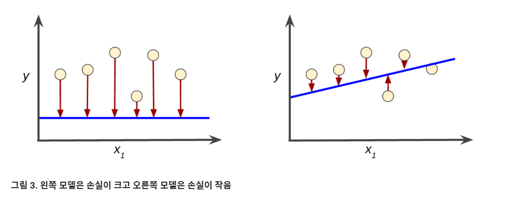

그림에서 보다시피, 왼쪽의 손실 직선의 길이가 오른쪽 손실 직선의 길이보다 훨씬 길다.  
따라서 오른쪽 모델이 왼쪽에 비해 훨씬 더 예측을 잘 한 모델이다.

유의미한 방식으로 개별 손실을 종합할 수 있는 수학적 함수 -> 손실 함수 를 만들 수 있을까??

#### 제곱 손실 : 잘 알려진 손실 함수

여기에서 살펴볼 선형 회귀 모델에서는 제곱 손실( 또는 L2 손실 )이라는 손실 함수를 사용한다.  
데이터 하나의 손실 제곱은 다음과 같이 나타낸다.

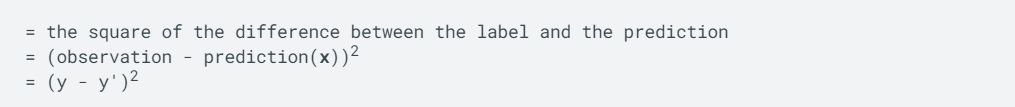

평균제곱오차 ( MSE = Mean Squared Error )는 예시당 평균 제곱 손실이다.  
MSE를 계산하려면 아래 수식처럼 개별 예의 모든 손실 을 합한 다음 예의 수로 나누면 된다.

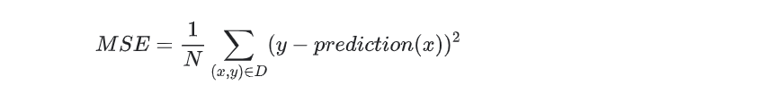

여기서

[output not shown]

MSE는 머신러닝에서 흔히 사용되지만, 모든 상황에서 최선인 유일한 손실함수는 아니다.

### 이해 확인을 위한 예제

- 다음 2개 도표를 살펴보고 도표에 표시된 2개의 DataSet중 MSE가 더 높은것은 무엇이고, 그 이유는 무엇인가??

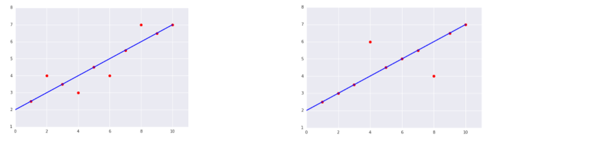

##### 해설)

```
    정답은 오른쪽의 데이터셋이 MSE가 더 높다.
    양쪽 그래프 둘다 손실의 합은 4로 같다.
    또한 예의 갯수도 같다.
    얼핏보면 평균 손실이 같아 보이지만, MSE 계산 식을 생각해보면 그렇지 않다.
    왼쪽의 데이터 셋에 대한 MSE계산 식은 아래와 같다.
```

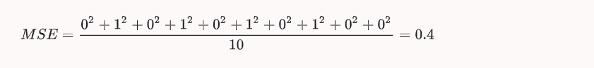

```
    오른쪽의 데이터 셋에 대한 MSE 계산 식은 아래와 같다.
```

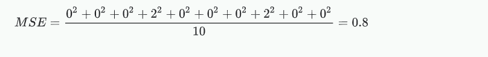

즉 MSE가 평균 제곱 오차 이기떄문에, 상대적으로 특정 예에서의 손실값이 크면, MSE는 더 높아진다.